# “An alternative to traditional clistering algorithms: Spectral Clustering”

Parziale Claudia & DIB Romy

4/26/2020

## Loading the dataset

```r
set.seed(123)
wine= read.table( "https://archive.ics.uci.edu/ml/machine-learning-databases/wine/wine.data",sep=",")
colnames(wine) <- c("Type","Alcohol","Malic acid","Ash",
                    "Alcalinity of ash", "Magnesium",
                    "Total phenols", "Flavanoids",
                    "Nonflavanoid phenols", "Proanthocyanins",
                    "Color intensity", "Hue",
                    "OD280/OD315 of diluted wines", "Proline")
```

##Exploratory analysis:

```r
head(wine)
```

```
##   Type Alcohol Malic acid  Ash Alcalinity of ash Magnesium Total phenols
## 1    1   14.23       1.71 2.43              15.6       127          2.80
## 2    1   13.20       1.78 2.14              11.2       100          2.65
## 3    1   13.16       2.36 2.67              18.6       101          2.80
## 4    1   14.37       1.95 2.50              16.8       113          3.85
## 5    1   13.24       2.59 2.87              21.0       118          2.80
## 6    1   14.20       1.76 2.45              15.2       112          3.27
##   Flavanoids Nonflavanoid phenols Proanthocyanins Color intensity  Hue
## 1       3.06                 0.28            2.29            5.64 1.04
## 2       2.76                 0.26            1.28            4.38 1.05
## 3       3.24                 0.30            2.81            5.68 1.03
## 4       3.49                 0.24            2.18            7.80 0.86
## 5       2.69                 0.39            1.82            4.32 1.04
## 6       3.39                 0.34            1.97            6.75 1.05
##   OD280/OD315 of diluted wines Proline
## 1                         3.92    1065
## 2                         3.40    1050
## 3                         3.17    1185
## 4                         3.45    1480
## 5                         2.93     735
## 6                         2.85    1450
```

```r
cat("Number of different wines in the dataset:", nrow(wine))
```

```
## Number of different wines in the dataset: 178
```

```r
cat("Number of features describing wines:", ncol(wine))
```

```
## Number of features describing wines: 14
```

```r
x=wine[,2:14] #drop column "type" we don't need to complete the analysis
summary(x)
```

```
##     Alcohol        Malic acid         Ash        Alcalinity of ash
##  Min.   :11.03   Min.   :0.740   Min.   :1.360   Min.   :10.60
##  1st Qu.:12.36   1st Qu.:1.603   1st Qu.:2.210   1st Qu.:17.20
##  Median :13.05   Median :1.865   Median :2.360   Median :19.50
##  Mean   :13.00   Mean   :2.336   Mean   :2.367   Mean   :19.49
##  3rd Qu.:13.68   3rd Qu.:3.083   3rd Qu.:2.558   3rd Qu.:21.50
##  Max.   :14.83   Max.   :5.800   Max.   :3.230   Max.   :30.00
##    Magnesium      Total phenols     Flavanoids    Nonflavanoid phenols
##  Min.   : 70.00   Min.   :0.980   Min.   :0.340   Min.   :0.1300
##  1st Qu.: 88.00   1st Qu.:1.742   1st Qu.:1.205   1st Qu.:0.2700
##  Median : 98.00   Median :2.355   Median :2.135   Median :0.3400
##  Mean   : 99.74   Mean   :2.295   Mean   :2.029   Mean   :0.3619
##  3rd Qu.:107.00   3rd Qu.:2.800   3rd Qu.:2.875   3rd Qu.:0.4375
##  Max.   :162.00   Max.   :3.880   Max.   :5.080   Max.   :0.6600
##  Proanthocyanins Color intensity       Hue         OD280/OD315 of diluted wines
##  Min.   :0.410   Min.   : 1.280   Min.   :0.4800   Min.   :1.270
##  1st Qu.:1.250   1st Qu.: 3.220   1st Qu.:0.7825   1st Qu.:1.938
##  Median :1.555   Median : 4.690   Median :0.9650   Median :2.780
##  Mean   :1.591   Mean   : 5.058   Mean   :0.9574   Mean   :2.612
##  3rd Qu.:1.950   3rd Qu.: 6.200   3rd Qu.:1.1200   3rd Qu.:3.170
##  Max.   :3.580   Max.   :13.000   Max.   :1.7100   Max.   :4.000
##     Proline
##  Min.   : 278.0
##  1st Qu.: 500.5
##  Median : 673.5
##  Mean   : 746.9
##  3rd Qu.: 985.0
##  Max.   :1680.0
```

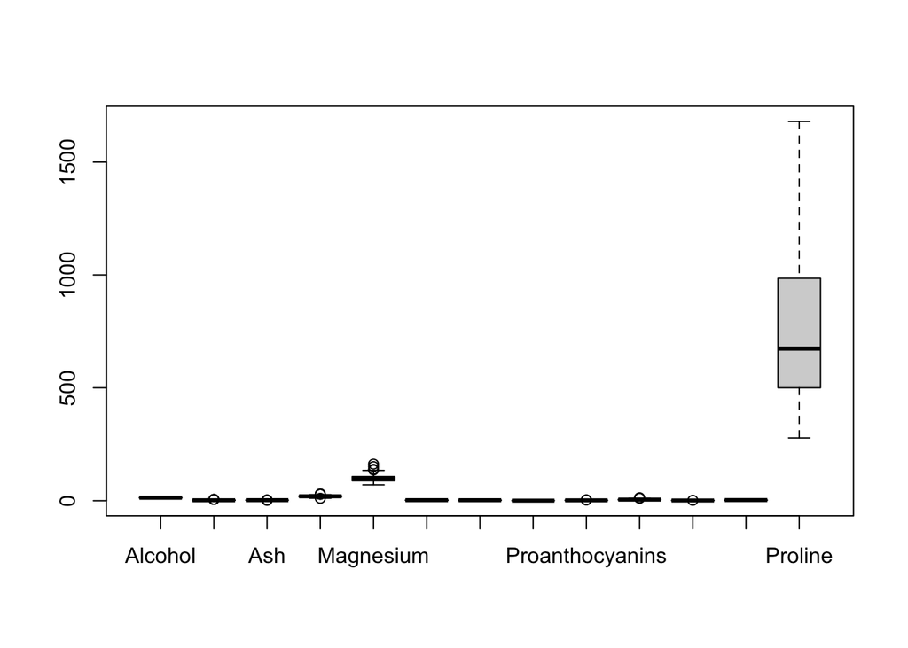

```r
boxplot(x)
```

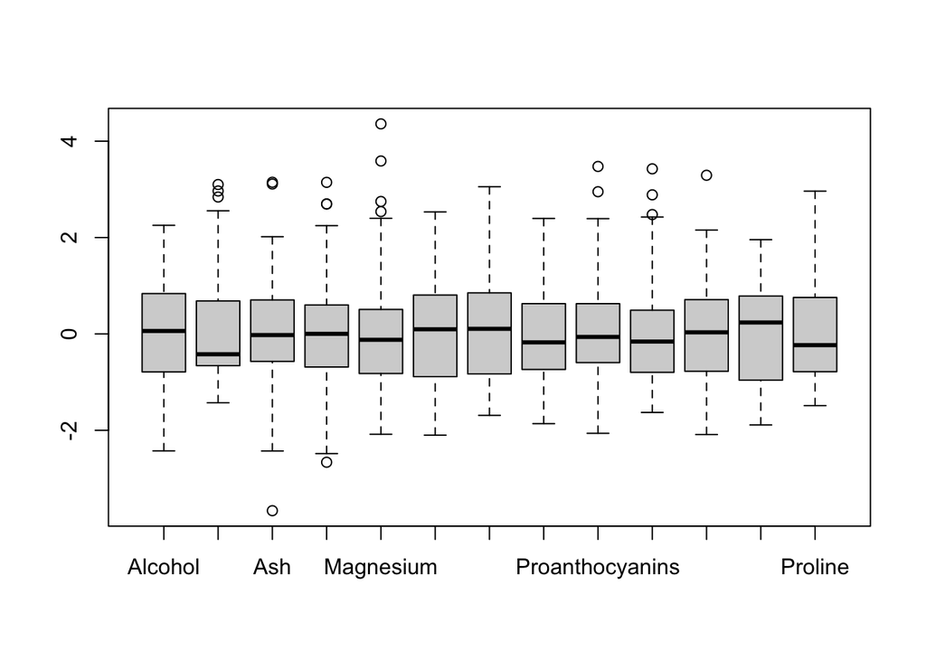

```r
x.stand=scale(x)
boxplot(x.stand)
```

Next step we will examining the relationship between variables:

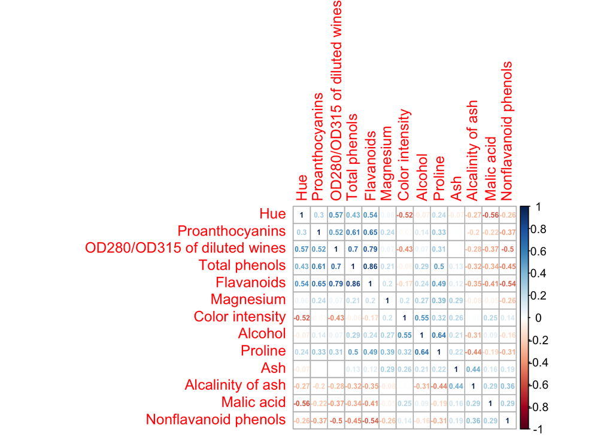

```r
library(corrplot)
wine_matrix <- data.matrix(x.stand, rownames.force = NA)
M <- cor(wine_matrix)
corrplot(M, method = "number", number.cex = 0.5, order="hclust")
```

From the correlation matrix we can see that dataset contains some highly correlated features, eg. flavanoids and total phenols (0.86). The highest dependencies (over 0.6) are mainly positive.

Then, we check if the dataset contains outliers through interquartile range statistic:

```r
vars <- c(colnames(x.stand))
Outliers <- c()
for(i in vars){
  max <- quantile(x.stand[,i], 0.75) + (IQR(x.stand[,i]) * 1.5 )
  min <- quantile(x.stand[,i], 0.25) - (IQR(x.stand[,i]) * 1.5 )
  idx <- which(x.stand[i] < min | x.stand[,i] > max)
  print(paste(i, length(idx), sep=' ')) # printing variable and number of potential outliers
  Outliers <- c(Outliers, idx)
  }
```

```
## [1] "Alcohol 0"
## [1] "Malic acid 3"
## [1] "Ash 2"
## [1] "Alcalinity of ash 3"
## [1] "Magnesium 4"
## [1] "Total phenols 0"
## [1] "Flavanoids 0"
## [1] "Nonflavanoid phenols 0"
## [1] "Proanthocyanins 2"
## [1] "Color intensity 4"
## [1] "Hue 1"
## [1] "OD280/OD315 of diluted wines 0"
## [1] "Proline 0"
```

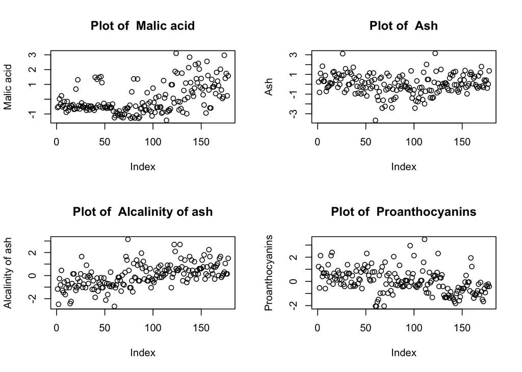

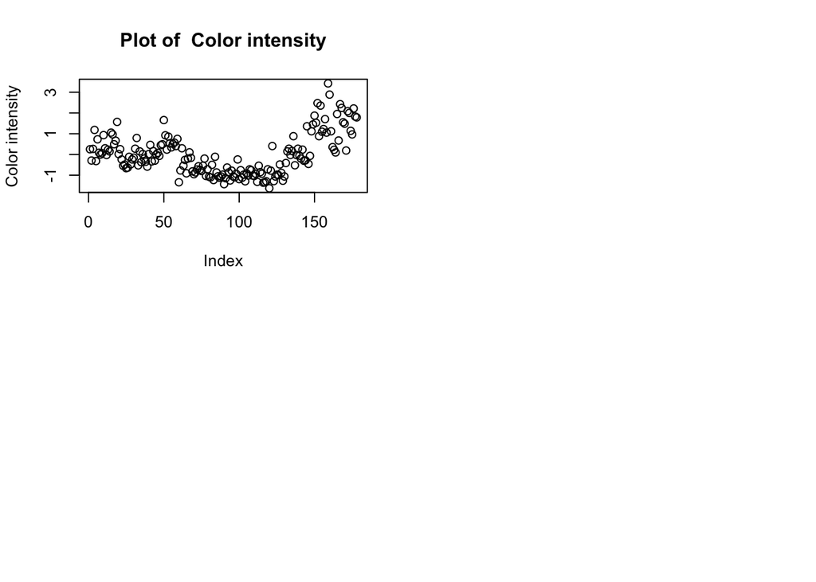

```r
#We plot the variables
par(mfrow=c(2,2))
colnames <- colnames(x.stand[,c(2,3,4,9,10)])
for (i in colnames) {
  plot(x.stand[,i], main = paste("Plot of ", i), ylab = i)
}
```

We decide to keep them. In order to choose the clustering algorithm best fitted to the data, owe must consider characteristics of the dataset. From initial analysis,we know that we deal with continuous variables and most of them are correlated (mainly positively). Dataset doesn’t contain worrisome outliers.

##Prediagnostic

We use the Hopkins statistic in order to check wheather data can be clustered and also to choose the optimal number of clusters.

```r
library(clustertend)
library(factoextra)
```

```
## $hopkins_stat
## [1] 0.656116
##
## $plot
```

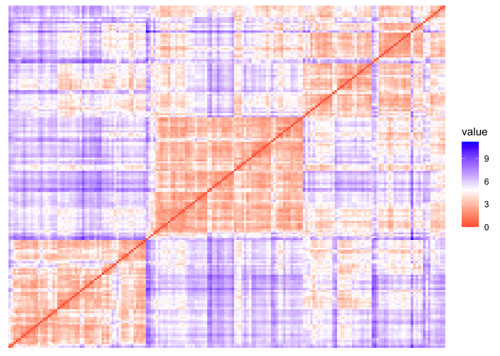

```r
get_clust_tendency(x.stand,3, graph=TRUE, gradient=list(low="red", mid="white", high="blue"))
```

We obtain H=0.656.

We now try to find the best number of clusters with silhouette statistic and apply it to three flat clustering algorithms: k-means, PAM and CLARA, hierarchical clustering and fuzzy clustering.

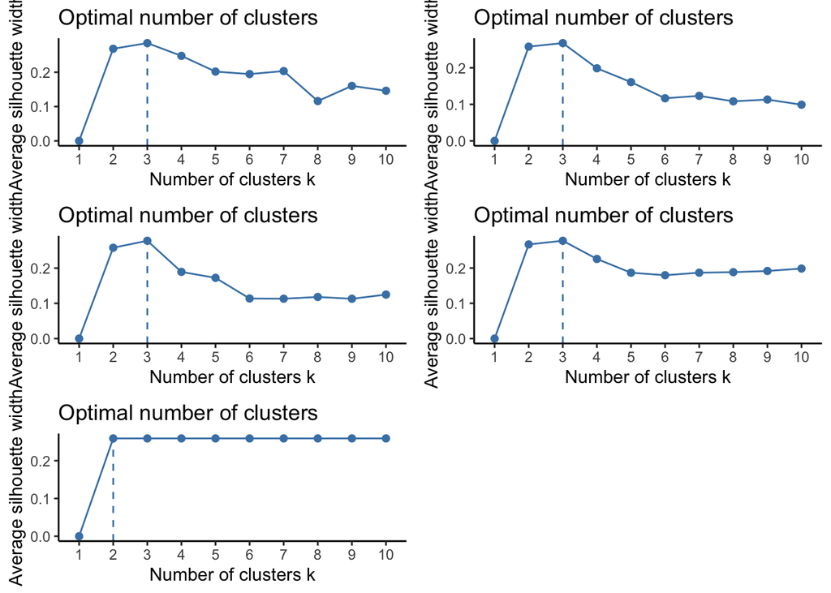

```r
library(gridExtra)
a <- fviz_nbclust(x.stand, FUNcluster = kmeans, method = "silhouette") + theme_classic()
b <- fviz_nbclust(x.stand, FUNcluster = cluster::pam, method = "silhouette") + theme_classic()
c <- fviz_nbclust(x.stand, FUNcluster = cluster::clara, method = "silhouette") + theme_classic()
d <- fviz_nbclust(x.stand, FUNcluster = hcut, method = "silhouette") + theme_classic()
e <- fviz_nbclust(x.stand ,FUNcluster = cluster::fanny, method = "silhouette") + theme_classic()
grid.arrange(a, b, c, d, e, ncol=2)
```

#Another method:

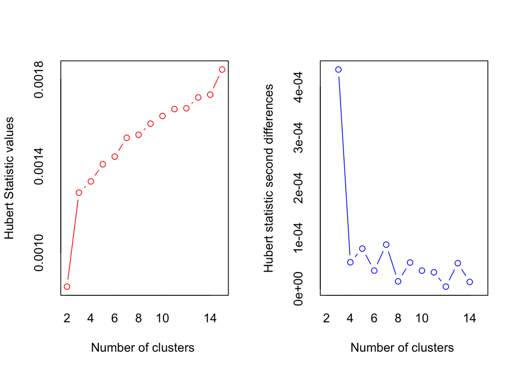

```
## *** : The Hubert index is a graphical method of determining the number of clusters.
##                 In the plot of Hubert index, we seek a significant knee that corresponds to a
##                 significant increase of the value of the measure i.e the significant peak in Hubert
##                 index second differences plot.
##
```

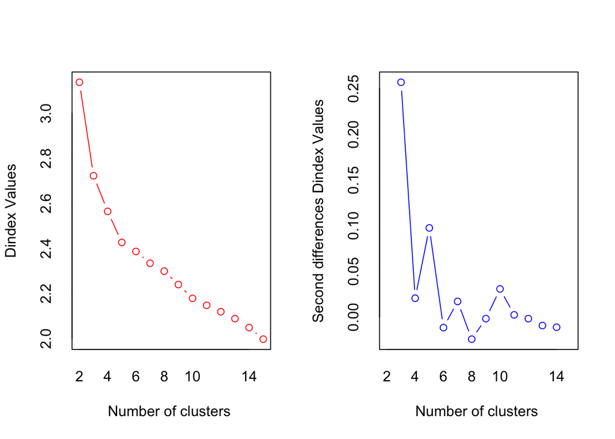

```
## *** : The D index is a graphical method of determining the number of clusters.
##                 In the plot of D index, we seek a significant knee (the significant peak in Dindex
##                 second differences plot) that corresponds to a significant increase of the value of
##                 the measure.
##
## * Among all indices:
## * 1 proposed 2 as the best number of clusters
## * 11 proposed 3 as the best number of clusters
## * 5 proposed 5 as the best number of clusters
## * 1 proposed 8 as the best number of clusters
## * 1 proposed 9 as the best number of clusters
## * 1 proposed 12 as the best number of clusters
## * 3 proposed 15 as the best number of clusters
##
##                    ***** Conclusion *****
##
## * According to the majority rule, the best number of clusters is  3
##
##
```

```
##         KL         CH   Hartigan        CCC      Scott    Marriot     TrCovW
##          5          3          3         15          3          3          3
##     TraceW   Friedman      Rubin     Cindex         DB Silhouette       Duda
##          3          3          5          3         12          3          5
##   PseudoT2      Beale  Ratkowsky       Ball PtBiserial       Frey    McClain
##          5          5          3          3          8          1          2
##       Dunn     Hubert    SDindex     Dindex       SDbw
##         15          0          9          0         15
```

```r
#another check
#detecting number of clusters:
library(NbClust)
NbClust(x.stand, method = 'complete', index = 'all')$Best.nc[1,]
```

The optimal number of clusters seems to be 3, as in fact are the types of wine.

###K-means algorithm

```r
result=kmeans(x.stand,3)
result$centers #the centers of each variable
```

```
##      Alcohol Malic acid        Ash Alcalinity of ash   Magnesium Total phenols
## 1  0.8328826 -0.3029551  0.3636801        -0.6084749  0.57596208    0.88274724
## 2  0.1644436  0.8690954  0.1863726         0.5228924 -0.07526047   -0.97657548
## 3 -0.9234669 -0.3929331 -0.4931257         0.1701220 -0.49032869   -0.07576891
##    Flavanoids Nonflavanoid phenols Proanthocyanins Color intensity        Hue
## 1  0.97506900          -0.56050853      0.57865427       0.1705823  0.4726504
## 2 -1.21182921           0.72402116     -0.77751312       0.9388902 -1.1615122
## 3  0.02075402          -0.03343924      0.05810161      -0.8993770  0.4605046
##   OD280/OD315 of diluted wines    Proline
## 1                    0.7770551  1.1220202
## 2                   -1.2887761 -0.4059428
## 3                    0.2700025 -0.7517257
```

```r
table(wine$Type, result$cluster )
```

```
##
##      1  2  3
##   1 59  0  0
##   2  3  3 65
##   3  0 48  0
```

It did a good job with type 1 and 3 but less with type 2.

###Hierarchial Clustering

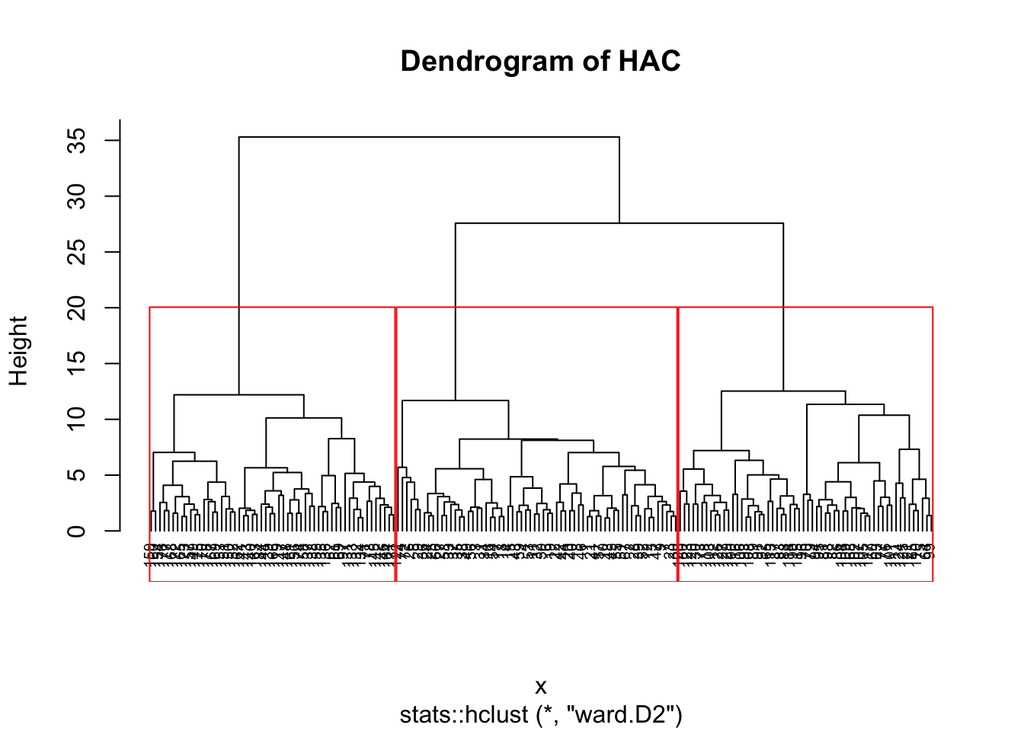

```r
hc <- eclust(x.stand, k=3, FUNcluster="hclust", hc_metric="euclidean", hc_method = "ward.D2")
plot(hc, cex=0.6, hang=-1, main = "Dendrogram of HAC")
rect.hclust(hc, k=3, border='red')
```

```r
table(wine$Type,hc$cluster)
```

```
##
##      1  2  3
##   1 59  0  0
##   2  5 58  8
##   3  0  0 48
```

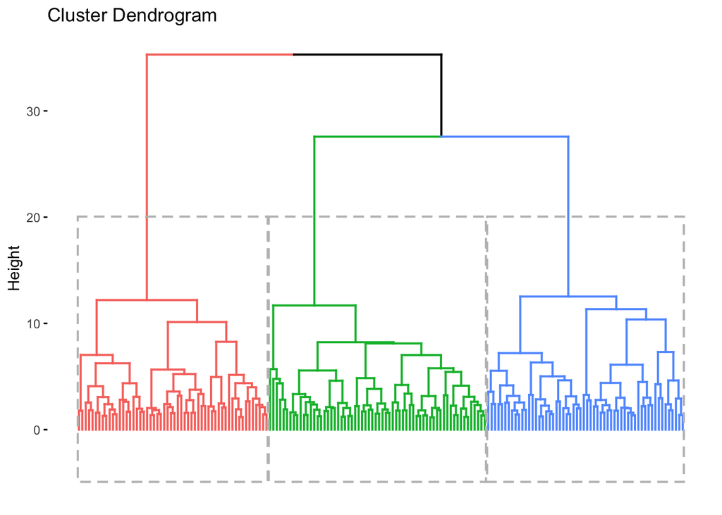

```r
fviz_dend(hc, rect = TRUE, show_labels = FALSE)
```

##Spectral analysis without packages

```r
nodes <- dim(x.stand)[1]
S <- matrix(NA,nrow=nodes,ncol=nodes) #similarity matrix with gaussin karnel
sigma <- 1.5
for(i in 1:nodes){
  for(j in 1:nodes){
    S[i,j] <- exp(-sum((x.stand[i,] - x.stand[j,])^2)/(2*sigma^2))
  }
}
#degree matrix
S_degree <- rowSums(S)
#Laplacian matrix
Laplacian <- diag(S_degree) - S
normalized_Laplacian <- diag(S_degree^(-1/2)) %*% S %*% diag(S_degree^(-1/2))
ev <- eigen(Laplacian)
e <- kmeans(ev$vectors[,which.min(ev$values)],3)$cluster
table(wine$Type,e)
```

```
##    e
##      1  2  3
##   1  4  4 51
##   2 29  0 42
##   3 48  0  0
```

It performs weaker than the others method. We attribute can this anomaly to the curse of dimensionality: 13 dimensions for only 178 points.

###Spectral clustering with kernlab package

```r
library(kernlab)
spec.alg=specc(as.matrix(wine[-1]),centers=3)
spec.alg
```

```
## Spectral Clustering object of class "specc"
##
##  Cluster memberships:
##
## 3 3 3 1 2 1 3 3 3 3 1 3 3 3 1 3 3 3 1 2 2 2 3 3 2 2 3 3 3 3 3 1 3 3 3 3 2 3 3 2 2 3 3 2 2 3 3 3 3 3 3 3 3 3 3 3 3 3 3 2 2 2 2 2 2 2 2 2 2 2 2 2 2 3 2 2 2 2 2 2 2 2 2 2 2 2 2 2 2 2 2 2 2 2 2 3 2 2 2 2 2 2 2 2 2 2 2 2 2 2 2 2 2 2 2 2 2 2 2 2 2 2 2 2 2 2 2 2 2 2 2 2 2 2 2 2 2 2 2 2 2 2 2 2 2 2 2 2 2…
##
## Gaussian Radial Basis kernel function.
##  Hyperparameter : sigma =  0.000573116875496677
##
## Centers:
##          [,1]     [,2]     [,3]     [,4]      [,5]     [,6]     [,7]      [,8]
## [1,] 14.13667 1.831667 2.411667 16.26667 107.66667 3.255000 3.493333 0.2716667
## [2,] 12.69906 2.516563 2.342188 20.39922  97.07812 2.075156 1.650937 0.3910156
## [3,] 13.72295 1.880909 2.431136 17.30455 106.40909 2.804091 2.930227 0.2893182
##          [,9]    [,10]     [,11]    [,12]     [,13]
## [1,] 2.216667 7.233333 1.1133333 3.028333 1530.3333
## [2,] 1.456953 4.844687 0.9085625 2.414219  578.1484
## [3,] 1.895227 5.382273 1.0784091 3.129318 1130.9545
##
## Cluster size:
## [1]   6 128  44
##
## Within-cluster sum of squares:
## [1]  23211114  81128668 102606273
```

###PCA ANALYSIS

```r
library(cluster)
library(fpc)
library(NbClust)
W.pca <- princomp(x.stand, cor = TRUE, scores = TRUE, covmat = NULL)
summary(W.pca)
```

```
## Importance of components:
##                           Comp.1    Comp.2    Comp.3    Comp.4     Comp.5
## Standard deviation     2.1692972 1.5801816 1.2025273 0.9586313 0.92370351
## Proportion of Variance 0.3619885 0.1920749 0.1112363 0.0706903 0.06563294
## Cumulative Proportion  0.3619885 0.5540634 0.6652997 0.7359900 0.80162293
##                            Comp.6     Comp.7     Comp.8     Comp.9    Comp.10
## Standard deviation     0.80103498 0.74231281 0.59033665 0.53747553 0.50090167
## Proportion of Variance 0.04935823 0.04238679 0.02680749 0.02222153 0.01930019
## Cumulative Proportion  0.85098116 0.89336795 0.92017544 0.94239698 0.96169717
##                           Comp.11    Comp.12     Comp.13
## Standard deviation     0.47517222 0.41081655 0.321524394
## Proportion of Variance 0.01736836 0.01298233 0.007952149
## Cumulative Proportion  0.97906553 0.99204785 1.000000000
```

```r
summary(W.pca)
```

```
## Importance of components:
##                           Comp.1    Comp.2    Comp.3    Comp.4     Comp.5
## Standard deviation     2.1692972 1.5801816 1.2025273 0.9586313 0.92370351
## Proportion of Variance 0.3619885 0.1920749 0.1112363 0.0706903 0.06563294
## Cumulative Proportion  0.3619885 0.5540634 0.6652997 0.7359900 0.80162293
##                            Comp.6     Comp.7     Comp.8     Comp.9    Comp.10
## Standard deviation     0.80103498 0.74231281 0.59033665 0.53747553 0.50090167
## Proportion of Variance 0.04935823 0.04238679 0.02680749 0.02222153 0.01930019
## Cumulative Proportion  0.85098116 0.89336795 0.92017544 0.94239698 0.96169717
##                           Comp.11    Comp.12     Comp.13
## Standard deviation     0.47517222 0.41081655 0.321524394
## Proportion of Variance 0.01736836 0.01298233 0.007952149
## Cumulative Proportion  0.97906553 0.99204785 1.000000000
```

```r
loadings(W.pca)
```

```
##
## Loadings:
##                              Comp.1 Comp.2 Comp.3 Comp.4 Comp.5 Comp.6 Comp.7
## Alcohol                       0.144  0.484  0.207         0.266  0.214
## Malic acid                   -0.245  0.225        -0.537         0.537 -0.421
## Ash                                  0.316 -0.626  0.214  0.143  0.154  0.149
## Alcalinity of ash            -0.239        -0.612               -0.101  0.287
## Magnesium                     0.142  0.300 -0.131  0.352 -0.727        -0.323
## Total phenols                 0.395        -0.146 -0.198  0.149
## Flavanoids                    0.423        -0.151 -0.152  0.109
## Nonflavanoid phenols         -0.299        -0.170  0.203  0.501 -0.259 -0.595
## Proanthocyanins               0.313        -0.149 -0.399 -0.137 -0.534 -0.372
## Color intensity                      0.530  0.137               -0.419  0.228
## Hue                           0.297 -0.279         0.428  0.174  0.106 -0.232
## OD280/OD315 of diluted wines  0.376 -0.164 -0.166 -0.184  0.101  0.266
## Proline                       0.287  0.365  0.127  0.232  0.158  0.120
##                              Comp.8 Comp.9 Comp.10 Comp.11 Comp.12 Comp.13
## Alcohol                       0.396  0.509  0.212   0.226   0.266
## Malic acid                                 -0.309          -0.122
## Ash                          -0.170 -0.308          0.499          -0.141
## Alcalinity of ash             0.428  0.200         -0.479
## Magnesium                    -0.156  0.271
## Total phenols                -0.406  0.286 -0.320  -0.304   0.304  -0.464
## Flavanoids                   -0.187        -0.163                   0.832
## Nonflavanoid phenols         -0.233  0.196  0.216  -0.117           0.114
## Proanthocyanins               0.368 -0.209  0.134   0.237          -0.117
## Color intensity                            -0.291          -0.604
## Hue                           0.437        -0.522          -0.259
## OD280/OD315 of diluted wines         0.137  0.524          -0.601  -0.157
## Proline                       0.120 -0.576  0.162  -0.539
##
##                Comp.1 Comp.2 Comp.3 Comp.4 Comp.5 Comp.6 Comp.7 Comp.8 Comp.9
## SS loadings     1.000  1.000  1.000  1.000  1.000  1.000  1.000  1.000  1.000
## Proportion Var  0.077  0.077  0.077  0.077  0.077  0.077  0.077  0.077  0.077
## Cumulative Var  0.077  0.154  0.231  0.308  0.385  0.462  0.538  0.615  0.692
##                Comp.10 Comp.11 Comp.12 Comp.13
## SS loadings      1.000   1.000   1.000   1.000
## Proportion Var   0.077   0.077   0.077   0.077
## Cumulative Var   0.769   0.846   0.923   1.000
```

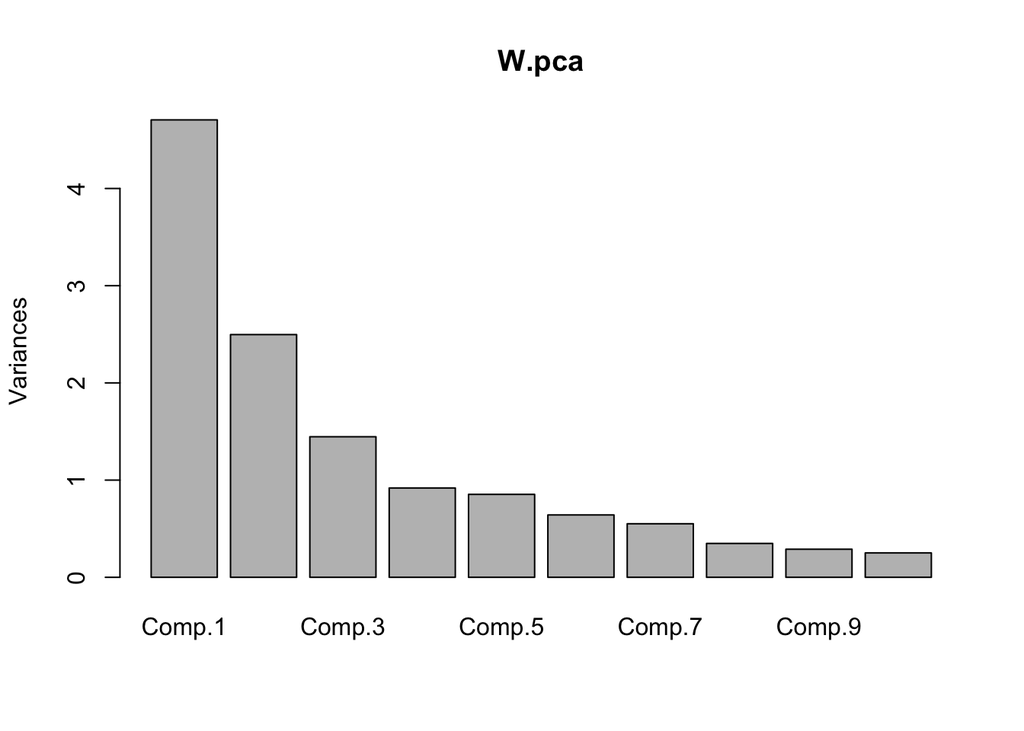

```r
plot(W.pca)
```

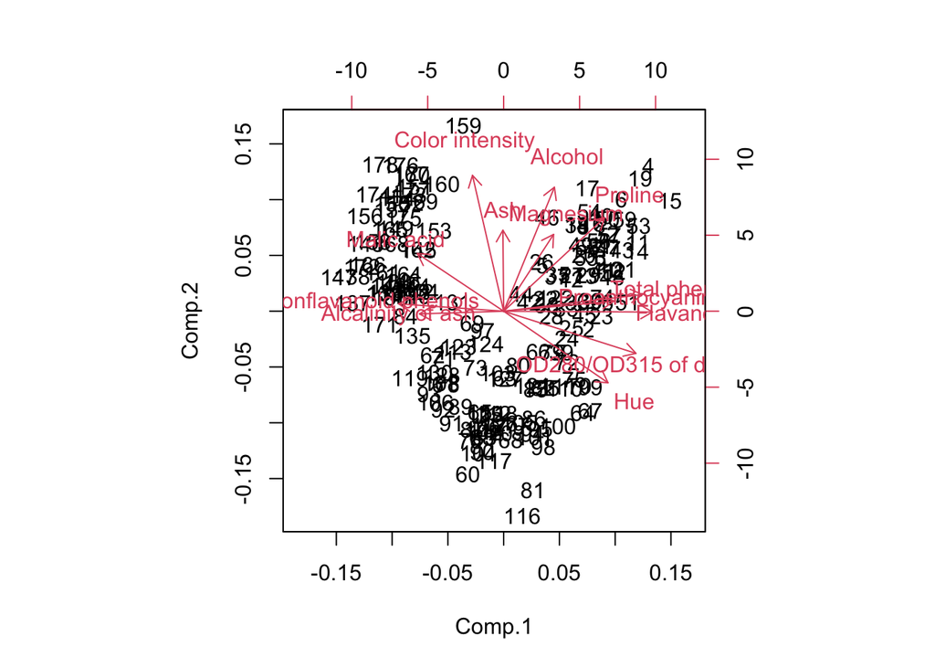

```r
biplot(W.pca)
```

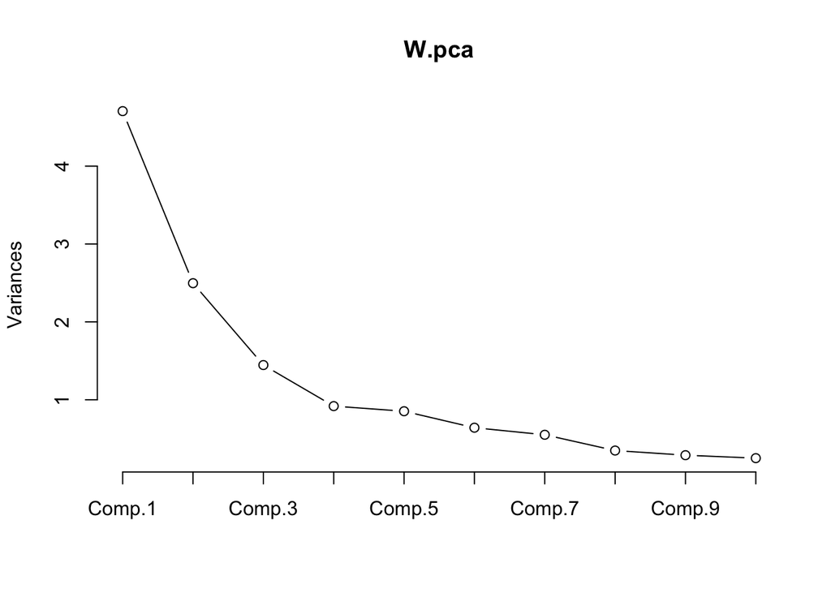

```r
plot(W.pca, type='l')
```

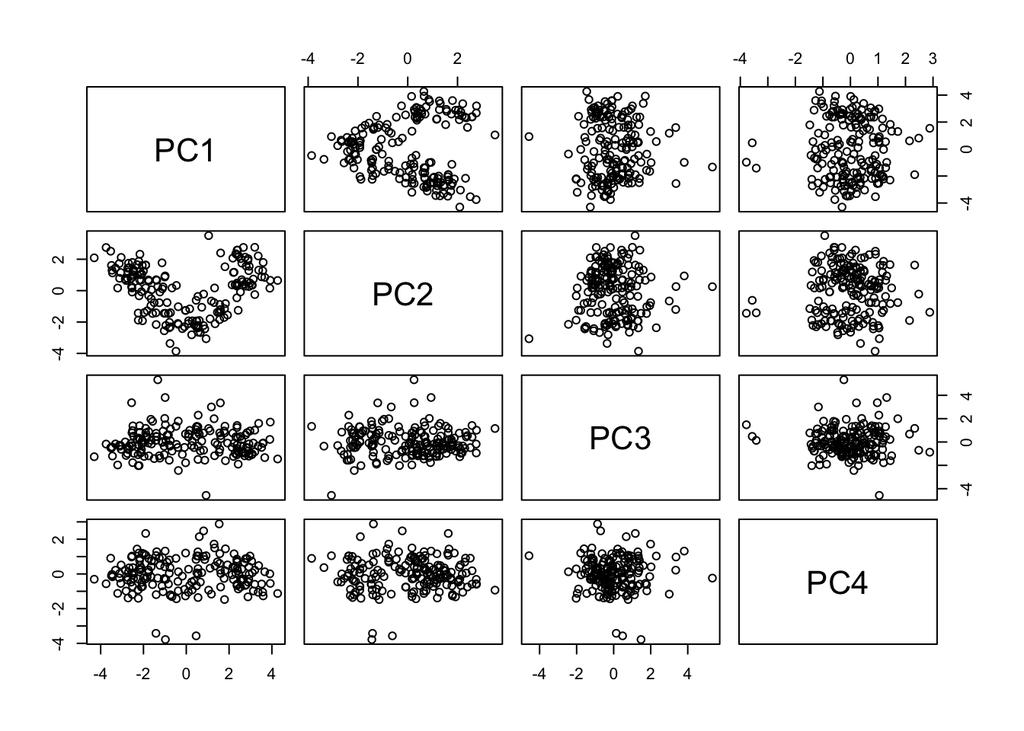

```r
pc=prcomp(x.stand)
comp=data.frame(pc$x[,1:4])
plot(comp)
```

```r
head(comp)
```

```
##         PC1        PC2        PC3        PC4
## 1 -3.307421  1.4394023 -0.1652728  0.2150246
## 2 -2.203250 -0.3324551 -2.0207571  0.2905387
## 3 -2.509661  1.0282507  0.9800541 -0.7228632
## 4 -3.746497  2.7486184 -0.1756962 -0.5663856
## 5 -1.006070  0.8673840  2.0209873  0.4086131
## 6 -3.041674  2.1164309 -0.6276254  0.5141870
```

###K-means on principal components

```r
k=kmeans(comp,3)
# Cluster sizes
sort(table(k$clust))
```

```
##
##  2  1  3
## 51 62 65
```

```r
clust <- names(sort(table(k$clust)))
# First cluster
row.names(wine[k$clust==clust[1],])
```

```
##  [1] "62"  "84"  "119" "131" "132" "133" "134" "135" "136" "137" "138" "139"
## [13] "140" "141" "142" "143" "144" "145" "146" "147" "148" "149" "150" "151"
## [25] "152" "153" "154" "155" "156" "157" "158" "159" "160" "161" "162" "163"
## [37] "164" "165" "166" "167" "168" "169" "170" "171" "172" "173" "174" "175"
## [49] "176" "177" "178"
```

```r
# Second Cluster
row.names(wine[k$clust==clust[2],])
```

```
##  [1] "1"   "2"   "3"   "4"   "5"   "6"   "7"   "8"   "9"   "10"  "11"  "12"
## [13] "13"  "14"  "15"  "16"  "17"  "18"  "19"  "20"  "21"  "22"  "23"  "24"
## [25] "25"  "26"  "27"  "28"  "29"  "30"  "31"  "32"  "33"  "34"  "35"  "36"
## [37] "37"  "38"  "39"  "40"  "41"  "42"  "43"  "44"  "45"  "46"  "47"  "48"
## [49] "49"  "50"  "51"  "52"  "53"  "54"  "55"  "56"  "57"  "58"  "59"  "74"
## [61] "96"  "122"
```

```r
# Third Cluster
row.names(wine[k$clust==clust[3],])
```

```
##  [1] "60"  "61"  "63"  "64"  "65"  "66"  "67"  "68"  "69"  "70"  "71"  "72"
## [13] "73"  "75"  "76"  "77"  "78"  "79"  "80"  "81"  "82"  "83"  "85"  "86"
## [25] "87"  "88"  "89"  "90"  "91"  "92"  "93"  "94"  "95"  "97"  "98"  "99"
## [37] "100" "101" "102" "103" "104" "105" "106" "107" "108" "109" "110" "111"
## [49] "112" "113" "114" "115" "116" "117" "118" "120" "121" "123" "124" "125"
## [61] "126" "127" "128" "129" "130"
```

```r
table(wine$Type, k$cluster)
```

```
##
##      1  2  3
##   1 59  0  0
##   2  3  3 65
##   3  0 48  0
```

###Spectral clustering on PCA

```r
nodes <- dim(comp)[1]
S <- matrix(NA,nrow=nodes,ncol=nodes) #similarity matrix with gaussin karnel
sigma <- 1.5
for(i in 1:nodes){
  for(j in 1:nodes){
    S[i,j] <- exp(-sum((comp[i,] - comp[j,])^2)/(2*sigma^2))
  }
}
#degree matrix
S_degree <- rowSums(S)
#Laplacian matrix
Laplacian <- diag(S_degree) - S
normalized_Laplacian <- diag(S_degree^(-1/2)) %*% S %*% diag(S_degree^(-1/2))
ev <- eigen(Laplacian)
e <- kmeans(ev$vectors[,which.min(ev$values)],3)$cluster
table(wine$Type, e)
```

```
##    e
##      1  2  3
##   1 23  1 35
##   2 47 23  1
##   3  0 48  0
```